# Dimensionality reduction techniques

The following exercise is for dimensionality reduction techniques.

```r
library("ggplot2")
library("GGally")
library("corrplot")
library("tidyverse")
library("vtable")
library("FactoMineR")

human <- read.csv("data/human.cvs")
rownames(human) <- human$X
human <- select(human, -X)
```

The exercise is done by using the United Nations Development Programme data which is freely available. The data is available with explanations from the url below.

http://hdr.undp.org/en/content/human-development-index-hdi

We used only some of the variables available. Variables used were gross national income per capita (gnicap), secondary education proportion male/female (popseceduP), labour force proportion male/female (labrateP), life expectancy at birth (lifebirth), maternal mortality ratio (mmr), adolescent birth rate (abirth) and percentage of female representatives in parliament (prp).

```r
# Summary statistics
st(human)
```

Summary Statistics

| Variable | N | Mean | Std. Dev. | Min | Pctl. 25 | Pctl. 75 | Max |
| --- | --- | --- | --- | --- | --- | --- | --- |
| popseceduP | 155 | 0.853 | 0.242 | 0.172 | 0.726 | 0.997 | 1.497 |
| labrateP | 155 | 0.707 | 0.199 | 0.186 | 0.598 | 0.854 | 1.038 |
| lifebirth | 155 | 71.654 | 8.332 | 49 | 66.3 | 77.25 | 83.5 |
| mmr | 155 | 149.084 | 211.79 | 1 | 11.5 | 190 | 1100 |
| abirth | 155 | 47.159 | 41.112 | 0.6 | 12.65 | 71.95 | 204.8 |
| prp | 155 | 20.912 | 11.488 | 0 | 12.4 | 27.95 | 57.5 |
| gnicap | 155 | 17627.903 | 18543.852 | 581 | 4197.5 | 24512 | 123124 |

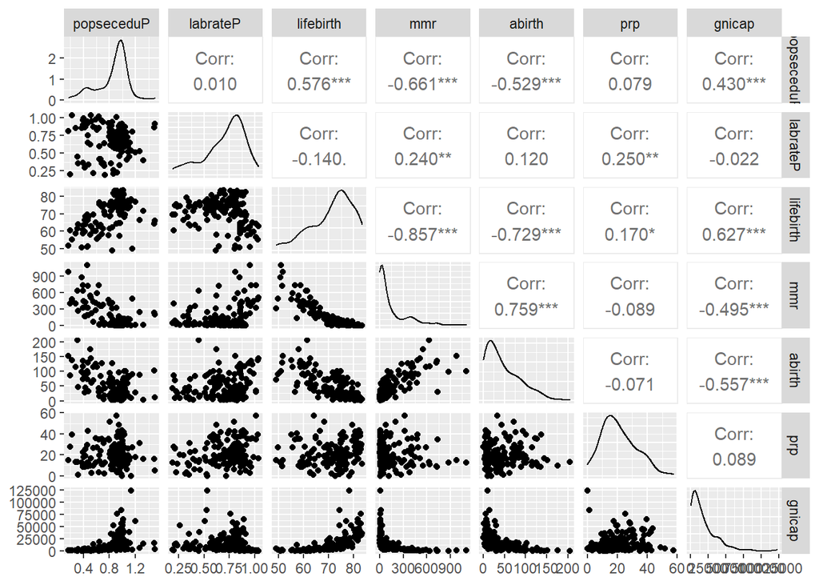

```r
ggpairs(human)
```

Only popsecedu2 of the variables looks like it might be standard distributed. Correlations are somewhat as expected, higher GNI countries have less maternal mortality and less adoslescent birth rate (fewer babies) but higher life expectancy at birth and proportion of females with secondary education. Also understandably there is a strong (negative) correlation between life expectancy and maternal mortality rate. Adolescent birth rate is negatively correlated with life expectancy at birth and positively with maternal mortality rate. Also secondary education proportion is correlated fairly strongly with life expectancy, maternal mortality rate and adoslescent birth rate.

```r
pca_human <- prcomp(human)
pca_human
```

```
## Standard deviations (1, .., p=7):
## [1] 1.854416e+04 1.855166e+02 2.518445e+01 1.144825e+01 3.734146e+00
## [6] 2.004983e-01 1.594657e-01
##
## Rotation (n x k) = (7 x 7):
##                      PC1           PC2           PC3           PC4
## popseceduP -5.607472e-06  0.0006714036 -3.514696e-05 -0.0002620825
## labrateP    2.331945e-07 -0.0002819674  5.278772e-04 -0.0046743437
## lifebirth  -2.815823e-04  0.0283153792  1.290783e-02 -0.0671093745
## mmr         5.655734e-03 -0.9916605713  1.259324e-01 -0.0059171414
## abirth      1.233961e-03 -0.1255518557 -9.919261e-01  0.0059333537
## prp        -5.526459e-05  0.0032309234 -7.516620e-03 -0.9976994508
## gnicap     -9.999832e-01 -0.0057717465 -5.149855e-04  0.0000478912
##                      PC5           PC6           PC7
## popseceduP -0.0028489667  6.639035e-01  7.478125e-01
## labrateP    0.0014434209  7.478087e-01 -6.638960e-01
## lifebirth   0.9972547027  5.520834e-04  3.260802e-03
## mmr         0.0261271494  1.856764e-04  8.289187e-04
## abirth      0.0168039116  4.333395e-04 -2.525059e-04
## prp        -0.0671404994 -3.713633e-03  2.688240e-03
## gnicap     -0.0001085808 -1.913832e-06 -1.038360e-06
```

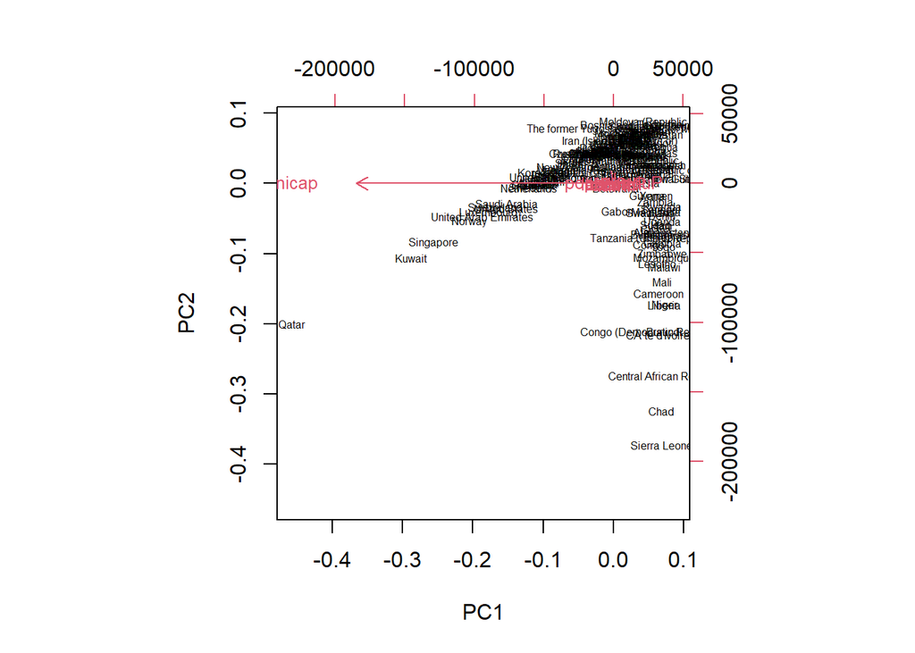

```r
biplot(pca_human, choises = 1:2, cex =c(0.5, 0.8))
```

Without standardization of the variables, the correlation naturally favors the gnicap as it has significantly larger value than any other variable. In fact the biplot above is mostly useless. Principal component 1 is dominated by the gnicap value as is also seen in the PCA table.

```r
human_std <- scale(human)
human_std_pca <- prcomp(human_std)
human_std_pca
```

```
## Standard deviations (1, .., p=7):
## [1] 1.8853909 1.1277699 0.8729226 0.7773374 0.6563069 0.5217013 0.3229207
##
## Rotation (n x k) = (7 x 7):
##                    PC1        PC2         PC3          PC4        PC5
## popseceduP -0.39680835 0.08249781 -0.27749277  0.594867895 -0.5800454
## labrateP    0.08795767 0.71602210 -0.60013568  0.043499672  0.2974827
## lifebirth  -0.48694386 0.01769349  0.09640197 -0.066425633  0.1837366
## mmr         0.48669893 0.09908190 -0.10775543 -0.244158612 -0.2012745
## abirth      0.45560671 0.03545242  0.03478382  0.062499058 -0.5411089
## prp        -0.07908554 0.67973897  0.70365258  0.009966551 -0.1363359
## gnicap     -0.38338546 0.08410849 -0.21352633 -0.759084126 -0.4351948
##                    PC6         PC7
## popseceduP  0.20526018  0.16211971
## labrateP   -0.14842875 -0.08362821
## lifebirth  -0.58711008  0.60861280
## mmr         0.31130461  0.73801103
## abirth     -0.68893873 -0.13643399
## prp         0.13126423 -0.02561923
## gnicap      0.04859511 -0.17995312
```

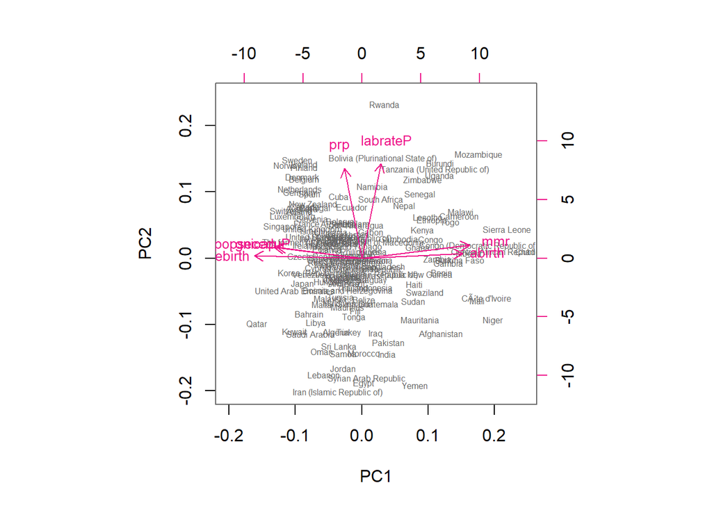

```r
biplot(human_std_pca, choises = 1:2, cex = c(0.5, 0.8), col = c("grey40", "deeppink2"))
```

Now we can much better see the results, and also now the results are more meaningful as the higher value of gni has replaced by standardized value. This allow us to more easily see how the principal component factors factor in. We can also see which variables have similar effect, aka. have correlation.

```r
data(tea)

# Lots of variables in the data, select only a few for clarity
keep_columns <- c("Tea", "price", "age_Q", "frequency", "sex", "SPC")

# select the 'keep_columns' to create a new dataset
tea <- select(tea, one_of(keep_columns))

# look at the summaries and structure of the data
summary(tea)
```

```
##         Tea                  price       age_Q          frequency   sex
##  black    : 74   p_branded      : 95   15-24:92   1/day      : 95   F:178
##  Earl Grey:193   p_cheap        :  7   25-34:69   1 to 2/week: 44   M:122
##  green    : 33   p_private label: 21   35-44:40   +2/day     :127
##                  p_unknown      : 12   45-59:61   3 to 6/week: 34
##                  p_upscale      : 53   +60  :38
##                  p_variable     :112
##
##            SPC
##  employee    :59
##  middle      :40
##  non-worker  :64
##  other worker:20
##  senior      :35
##  student     :70
##  workman     :12
```

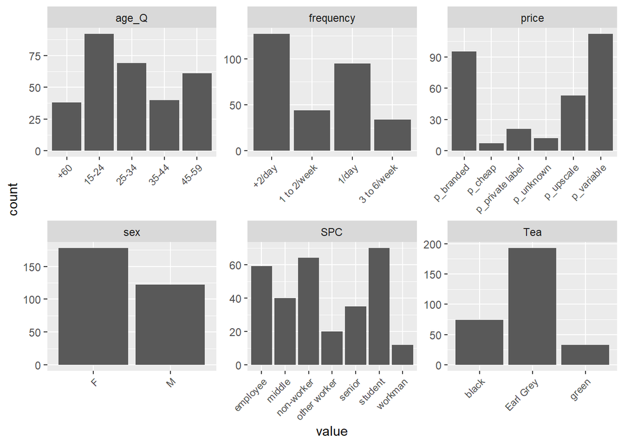

```r
# visualize the dataset
gather(tea) %>% ggplot(aes(value)) + facet_wrap("key", scales = "free") + geom_bar() + theme(axis.text.x = element_text(angle = 45, hjust = 1, size = 8))
```

```r
# multiple correspondence analysis
mca <- MCA(tea, graph = FALSE)

# summary of the model
summary(mca)
```

```
##
## Call:
## MCA(X = tea, graph = FALSE)
##
##
## Eigenvalues
##                        Dim.1   Dim.2   Dim.3   Dim.4   Dim.5   Dim.6   Dim.7
## Variance               0.340   0.304   0.227   0.220   0.199   0.196   0.191
## % of var.              9.712   8.684   6.481   6.294   5.680   5.602   5.469
## Cumulative % of var.   9.712  18.395  24.876  31.170  36.850  42.452  47.921
##                        Dim.8   Dim.9  Dim.10  Dim.11  Dim.12  Dim.13  Dim.14
## Variance               0.177   0.173   0.171   0.169   0.162   0.149   0.142
## % of var.              5.057   4.948   4.892   4.836   4.633   4.250   4.065
## Cumulative % of var.  52.977  57.926  62.818  67.654  72.287  76.537  80.602
##                       Dim.15  Dim.16  Dim.17  Dim.18  Dim.19  Dim.20  Dim.21
## Variance               0.134   0.126   0.115   0.113   0.091   0.054   0.045
## % of var.              3.841   3.587   3.292   3.235   2.605   1.551   1.286
## Cumulative % of var.  84.443  88.030  91.322  94.557  97.163  98.714 100.000
##
## Individuals (the 10 first)
##                    Dim.1    ctr   cos2    Dim.2    ctr   cos2    Dim.3    ctr
## 1               |  0.537  0.283  0.040 |  1.087  1.296  0.162 |  0.538  0.425
## 2               |  0.414  0.168  0.057 |  0.312  0.107  0.032 |  0.197  0.057
## 3               |  0.030  0.001  0.000 |  0.194  0.041  0.010 |  0.197  0.057
## 4               | -0.766  0.576  0.309 |  0.063  0.004  0.002 |  0.105  0.016
## 5               |  0.024  0.001  0.000 |  0.281  0.087  0.036 | -0.099  0.014
## 6               | -0.876  0.752  0.200 |  0.101  0.011  0.003 |  0.113  0.019
## 7               |  0.305  0.091  0.022 |  0.707  0.548  0.117 |  0.921  1.248
## 8               |  0.349  0.119  0.030 |  0.310  0.105  0.024 |  1.004  1.482
## 9               |  0.571  0.319  0.088 |  0.581  0.371  0.092 |  0.766  0.862
## 10              |  0.919  0.828  0.206 |  0.502  0.277  0.062 |  0.978  1.405
##                   cos2
## 1                0.040 |
## 2                0.013 |
## 3                0.010 |
## 4                0.006 |
## 5                0.004 |
## 6                0.003 |
## 7                0.199 |
## 8                0.250 |
```

[output cut: 20 more lines]

```
## p_cheap          -2.483 |   0.159   0.044   0.001   0.426 |
## p_private label   0.742 |   0.399   0.818   0.012   1.892 |
## p_unknown         4.917 |   0.434   0.554   0.008   1.533 |
## p_upscale        -0.381 |   0.430   2.403   0.040   3.447 |
## p_variable        0.401 |   0.375   3.864   0.084   5.009 |
## 15-24            -5.137 |   0.195   0.857   0.017   2.243 |
##
## Categorical variables (eta2)
##                   Dim.1 Dim.2 Dim.3
## Tea             | 0.324 0.014 0.232 |
## price           | 0.184 0.107 0.327 |
## age_Q           | 0.758 0.651 0.193 |
## frequency       | 0.013 0.139 0.286 |
## sex             | 0.072 0.206 0.001 |
## SPC             | 0.689 0.707 0.322 |
```

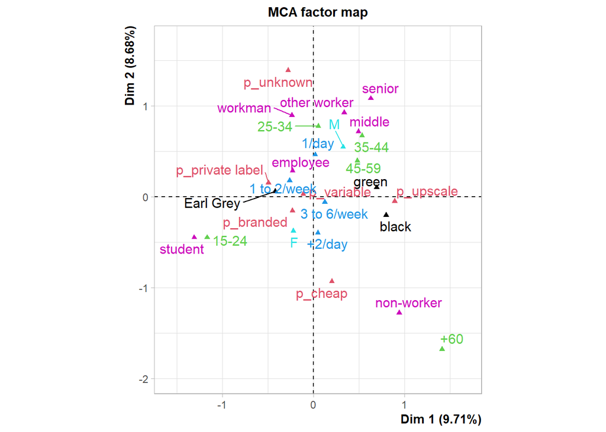

```r
# visualize MCA
plot(mca, invisible=c("ind"), habillage = "quali", graph.type = "ggplot")
```

My selected variables seem to be fairly equally distributed in the MCA dimensions. There are some slightly obviously related groups, like age 60+ and non-worker, perhaps surpricingly cheap price is also close to these. Students and young age also close by each other.